# Baby Names Investigation

Justin Post

# Investigating Names

We’ll be investigating the popularity of names in the US each year. The names of interest are:

- Justin
- Alexander
- Jacob
- Anderson
- George

# Read Data

Let’s read in some data to investigate! We’ll read in from two sources and combine the data into one object to look at.

```r
#from packages
data("BabyNames", package = "dcData")

#From file
BabyNamesSupp <-
  read_csv("https://github.com/jbpost2/Basics-of-R-for-Data-Science-and-Statistics/raw/master/datasets/BabyNamesSupp.csv",
           col_types = cols(sex = col_character()))  # fixes `sex`

BabyNamesFull <- bind_rows(BabyNames, BabyNamesSupp)
```

Now let’s subset the rows to only include names we have an interest in.

```r
BabyNamesFull %>%
  as_tibble() %>%
  filter(name %in% c("Justin", "Jacob", "Alexander", "George", "Anderson")) %>%
  arrange(desc(count))
```

```
## # A tibble: 1,065 x 4
##    name   sex   count  year
##    <chr>  <chr> <dbl> <dbl>
##  1 Jacob  M     35997  1998
##  2 Jacob  M     35344  1999
##  3 Justin M     35034  1988
##  4 Jacob  M     34462  2000
##  5 Jacob  M     34140  1997
##  6 Justin M     32842  1989
##  7 Jacob  M     32523  2001
##  8 Jacob  M     31908  1996
##  9 Justin M     31490  1987
## 10 Jacob  M     31118  1995
## # ... with 1,055 more rows
```

Jacob is very popular in the late 90’s.

## George

Let’s see how the name George has changed year to year by creating a new variable corresponding to the difference in count from one year to the next.

```r
BabyNamesFull %>%
  filter(name == "George" & sex == "M") %>%
  mutate(diff = count - lag(count))
```

```
##       name sex count year  diff
## 1   George   M  5126 1880    NA
## 2   George   M  4664 1881  -462
## 3   George   M  5193 1882   529
## 4   George   M  4736 1883  -457
## 5   George   M  4961 1884   225
## 6   George   M  4674 1885  -287
## 7   George   M  4671 1886    -3
## 8   George   M  4284 1887  -387
## 9   George   M  4912 1888   628
## 10  George   M  4430 1889  -482
## 11  George   M  4458 1890    28
## 12  George   M  3931 1891  -527
## 13  George   M  4760 1892   829
## 14  George   M  4320 1893  -440
```

[output cut: 126 more lines]

## Shannon and Lindsay

Let’s take a look at how these names have been used across time.

```r
BabyNamesFull %>%
  filter(name %in% c("Shannon", "Lindsay")) %>%
  pivot_wider(names_from = sex, values_from = count)
```

```
## # A tibble: 252 x 4
##    name     year     M     F
##    <chr>   <dbl> <dbl> <dbl>
##  1 Lindsay  1880     7    NA
##  2 Lindsay  1881     8    NA
##  3 Shannon  1881     5    NA
##  4 Lindsay  1882     9    NA
##  5 Lindsay  1884     9    NA
##  6 Lindsay  1885     6    NA
##  7 Shannon  1885     6    NA
##  8 Lindsay  1886     5    NA
##  9 Lindsay  1888     8    NA
## 10 Lindsay  1889    10    NA
## # ... with 242 more rows
```

```r
BabyNamesFull %>%
  filter(name %in% c("Shannon", "Lindsay")) %>%
  pivot_wider(names_from = sex, values_from = count) %>%
  group_by(name) %>%
  summarize(totalM = sum(M, na.rm = TRUE), totalF = sum(F, na.rm = TRUE))
```

```
## # A tibble: 2 x 3
##   name    totalM totalF
##   <chr>    <dbl>  <dbl>
## 1 Lindsay   5130 129666
## 2 Shannon  52061 295159
```

## Some summaries!

Let’s find out how many babies have been named each of the names we were investigating earlier. We’ll investigate the total number of times these names come up by their sex as assigned at birth.

```r
names <- c("Justin", "George", "Alexander", "Jacob", "Anderson")
BabyNamesFull %>%
    filter(name %in% names) %>%
    group_by(name, sex) %>%
    summarise(total = sum(count, na.rm = TRUE))
```

```
## # A tibble: 10 x 3
## # Groups:   name [5]
##    name      sex     total
##    <chr>     <chr>   <dbl>
##  1 Alexander F        4466
##  2 Alexander M      684145
##  3 Anderson  F         950
##  4 Anderson  M       28016
##  5 George    F        9942
##  6 George    M     1470178
##  7 Jacob     F        2259
##  8 Jacob     M      941483
##  9 Justin    F        3797
## 10 Justin    M      778247
```

Now let’s look at a contingency table of all names that occurred more than 50000 times in a given year. This will let us know how often the names have been really popular in a given year.

```r
BabyNamesFull %>%
  filter(count >50000) %>%
  pull(name) %>%
  table()
```

```
## .
##      Ashley Christopher       David     Deborah       Debra       James
##           1          12          25           3           1          49
##       Jason    Jennifer     Jessica        John       Linda        Lisa
##           6          14           3          49          10           5
##        Mark        Mary     Matthew     Michael    Patricia     Richard
##           6          46           1          46           4          12
##      Robert     William
##          51          26
```

Let’s investigate the total number of names in each year. We’ll group the data by year and find the sum of the count variable. This will let us know how many babies have been born across the years.

```r
BabyNamesFull %>%
  group_by(year) %>%
  summarize(total = sum(count)) %>%
  pull(total) %>%
  summary()
```

```
##    Min. 1st Qu.  Median    Mean 3rd Qu.    Max.
##  192700 1728436 3092162 2535652 3677142 4199919
```

## Visuals of the Data

Ok, now let’s visualize the number of times the five names of interest we have show up!

First, we can create a summary data set that has the number of times each one shows.

```r
names <- c("Justin", "George", "Alexander", "Jacob", "Anderson")
barData <- BabyNamesFull %>%
  filter(name %in% names) %>%
  group_by(name) %>%
  summarise(total = sum(count))
barData
```

```
## # A tibble: 5 x 2
##   name        total
##   <chr>       <dbl>
## 1 Alexander  688611
## 2 Anderson    28966
## 3 George    1480120
## 4 Jacob      943742
## 5 Justin     782044
```

Next, we can use `geom_bar()` to plot this and look at it in a nicer way.

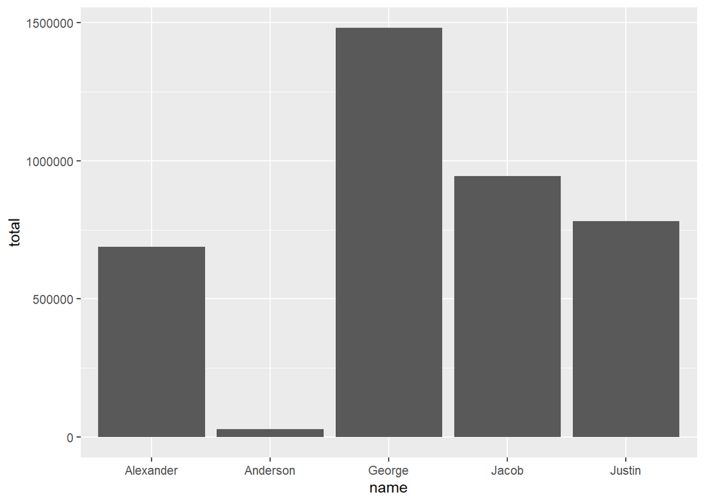

```r
ggplot(barData) +
 geom_bar(stat = "identity", aes(x = name, y = total))
```

Now let’s do the same thing but fill the plot by the sex variable.

```r
barDataSex <- BabyNamesFull %>%
  filter(name %in% c("Shannon", "Lindsay", "Avery")) %>%
  group_by(name, sex) %>%
  summarise(total = sum(count))
```

[figure not shown]

## Names over time

Ok, now let’s look at how our names have changed in popularity over time.

```r
lineData <- BabyNamesFull %>%
  filter(name %in% names) %>%
  group_by(name, year) %>%
  summarise(total = sum(count))
```

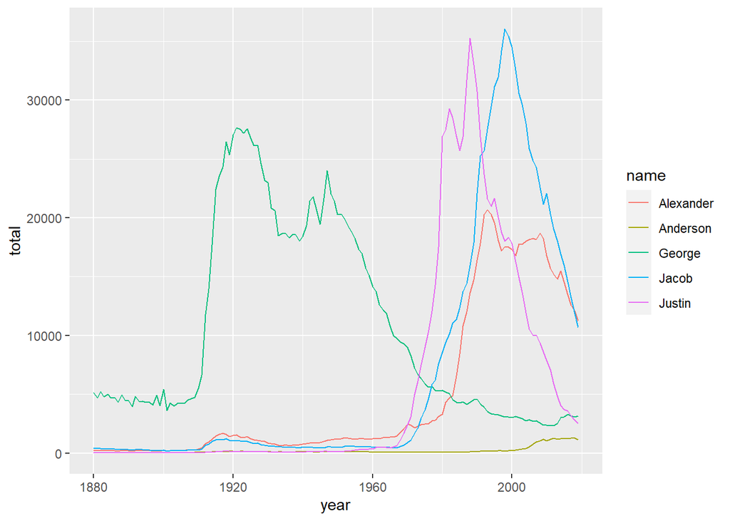

```r
## `summarise()` has grouped output by 'name'. You can override using the `.groups` argument.

ggplot(lineData) +
 geom_line(aes(x = year, y = total, color = name))
```